# movie rating

GAN LING

2017/4/12

#### load data

```r
library(ggplot2)
# before doing this, you need to use python to run the edit_users_movies_dat.py
# file to clean the dat data
# deal with users_clean.dat
users = read.csv("users_clean.dat", sep = "=", header = FALSE, col.names = c("UserID","Gender","Age","Occupation","Zip-code"))
# deal with movies_utf8_clean.dat
movie = read.csv("movies_utf8_clean.dat", sep = "=", header = FALSE, col.names = c("MovieID","Title","Genres"))
# deal with training_ratings_for_kaggle_comp.csv
# training_ratings = read.csv("training_ratings_for_kaggle_comp.csv")
# save(training_ratings, file = "training_ratings.RData")
load("training_ratings.RData")
```

#### combine the data, because this needs time, we can save the result for next time, this part we use one and half an hour to deal with the data and get 116858 observasions.

```r
combine_user = function (users, training_ratings, stopnum){
    k = 1
    for (d in training_ratings$user){
        if (d > stopnum){
            break
        }
        temp_row = data.frame(users[users$UserID == d, c(2,3,4)])
        # print(temp_row)
        if (k == 1){
            temp_get = temp_row
            k = 0
        }
        else{
            temp_get = rbind(temp_get, temp_row)
        }
    }
    cbind(training_ratings[1:nrow(temp_get),], temp_get)
}
# # get all of the data out when the rating equal to 5. Because we only care about the data with the highest evaluation.
# newraitings = combine_user(users, training_ratings[training_ratings$rating==5,], 6040)
# save(newraitings, file = "newraitings1.RData")

#load the data we save to save time
load("newraitings1.RData")
```

clean the data

```r
# see the structure of the data
str(newraitings)
```

```
## 'data.frame':    116858 obs. of  7 variables:
##  $ user      : int  2783 2783 2783 2783 2783 2783 2783 2783 2783 2783 ...
##  $ movie     : int  1253 589 741 750 924 1301 3175 1584 1748 2553 ...
##  $ rating    : int  5 5 5 5 5 5 5 5 5 5 ...
##  $ id        : Factor w/ 500100 levels "2783_1019","2783_1077",..: 11 42 45 46 47 14 33 20 21 27 ...
##  $ Gender    : Factor w/ 2 levels "F","M": 2 2 2 2 2 2 2 2 2 2 ...
##  $ Age       : int  45 45 45 45 45 45 45 45 45 45 ...
##  $ Occupation: int  17 17 17 17 17 17 17 17 17 17 ...
```

```r
# the column occupation is the index for the job of the evaluation person, then this column should be factor
newraitings$Occupation = as.factor(newraitings$Occupation)
# movie and user columns are also factors
newraitings$user = as.factor(newraitings$user)
newraitings$movie = as.factor(newraitings$movie)
# then we don't need rating and id columns anymore
newraitings = subset(newraitings, select = c(1, 2, 5, 6, 7))
str(newraitings)
```

```
## 'data.frame':    116858 obs. of  5 variables:
##  $ user      : Factor w/ 3225 levels "2783","2784",..: 1 1 1 1 1 1 1 1 1 1 ...
##  $ movie     : Factor w/ 2985 levels "1","2","3","4",..: 934 481 563 570 675 982 2422 1170 1289 1931 ...
##  $ Gender    : Factor w/ 2 levels "F","M": 2 2 2 2 2 2 2 2 2 2 ...
##  $ Age       : int  45 45 45 45 45 45 45 45 45 45 ...
##  $ Occupation: Factor w/ 21 levels "0","1","2","3",..: 18 18 18 18 18 18 18 18 18 18 ...
```

```r
head(newraitings, 10)
```

```
##    user movie Gender Age Occupation
## 1  2783  1253      M  45         17
## 2  2783   589      M  45         17
## 5  2783   741      M  45         17
## 6  2783   750      M  45         17
## 7  2783   924      M  45         17
## 17 2783  1301      M  45         17
## 25 2783  3175      M  45         17
## 28 2783  1584      M  45         17
## 29 2783  1748      M  45         17
## 30 2783  2553      M  45         17
```

1. the simplest way is to calculate the amount of the 5 star movies and sort them in decresing order, then we can get the best movies for us

```r
bestmovie1 = as.matrix(head(sort(table(newraitings$movie), decreasing = TRUE),10))
bestmovie1 = as.data.frame(bestmovie1)
names(bestmovie1) = "count"
bestmovie1 = cbind("movie_id" = rownames(bestmovie1), bestmovie1)
rownames(bestmovie1) <- NULL
```

find the movie information for the table

```r
# let the movie_id to factor first
movie$MovieID = as.factor(movie$MovieID)
k = 1
for (i in bestmovie1$movie_id){
    temp_row = data.frame(movie[movie$MovieID == i, c(2, 3)])
    if (k == 1){
        temp_get = temp_row
        k = 0
    }
    else{
        temp_get = rbind(temp_get, temp_row)
    }
}
bestmovie1 = cbind(bestmovie1[1:nrow(temp_get),], temp_get)
```

*For this approach, out ten highest movies are:*

```r
bestmovie1$Title
```

```
##  [1] American Beauty (1999)
##  [2] Star Wars: Episode IV - A New Hope (1977)
##  [3] Godfather, The (1972)
##  [4] Raiders of the Lost Ark (1981)
##  [5] Sixth Sense, The (1999)
##  [6] Shawshank Redemption, The (1994)
##  [7] Star Wars: Episode V - The Empire Strikes Back (1980)
##  [8] Matrix, The (1999)
##  [9] Schindler's List (1993)
## [10] Silence of the Lambs, The (1991)
## 3883 Levels: Not Love, Just Frenzy (M閱\xa9 que amor, frenes? (1996) ...
```

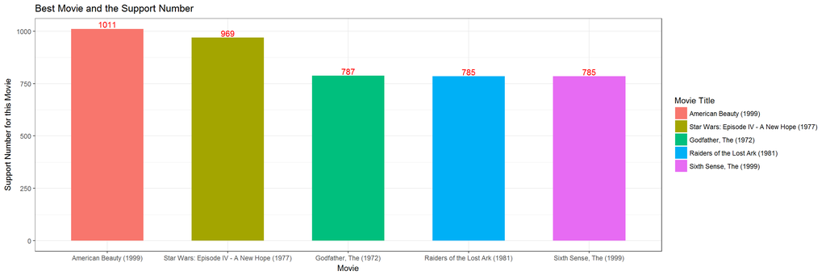

```r
# define the function to draw the 5 best movies
draw_best_movie = function (dataset, figuretitle = "Best Movie and the Support Number"){
    ggplot(data=dataset[1:5,], aes(x=reorder(Title, count[5:1]), fill=reorder(Title, count[5:1]), y = count)) +
    geom_bar(stat="identity" , width = 0.6) +
    geom_text(label=dataset[1:5,]$count, colour = "red", vjust=-0.2) +
    ggtitle(figuretitle) +
    labs(y="Support Number for this Movie", x="Movie", fill = "Movie Title") +
    theme_bw()

}
draw_best_movie(bestmovie1)
```

2. select the best movie group by Age

How many observers do we have? assemble the user information

```r
user_freq = as.data.frame(table(newraitings$user))
colnames(user_freq) = c("user_id", "5_star_count")
# write the user information in it
users$UserID = as.factor(users$UserID)
k = 1
for (d in user_freq$user_id){
    temp_row = data.frame(users[users$UserID == d, c(2,3,4)])
    if (k == 1){
        temp_get = temp_row
        k = 0
    }
    else{
        temp_get = rbind(temp_get, temp_row)
    }
}
user_freq = cbind(user_freq[1:nrow(temp_get),], temp_get)
```

*draw some pictures*

===================================

see the relation for the gender of the users

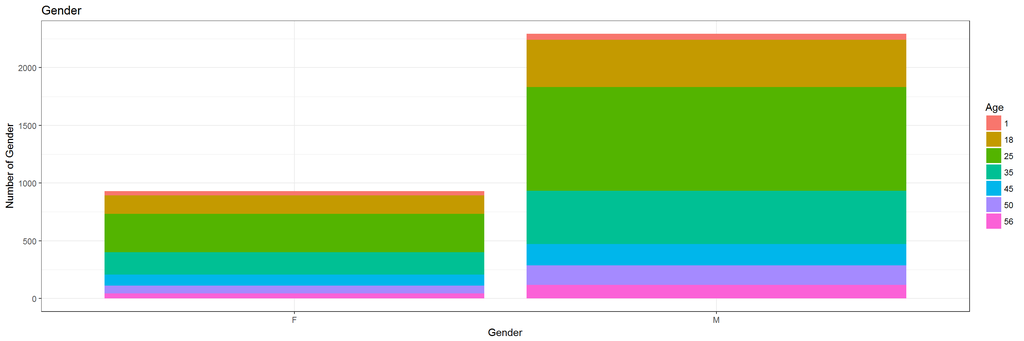

```r
Agefill = as.factor(user_freq$Age)
ggplot(data=user_freq, aes(x=Gender, fill=Agefill)) +
    geom_bar() +
    ggtitle("Gender") +
    labs(y="Number of Gender", x="Gender", fill = "Age") +
    theme_bw()
```

From the picture we can see that there are two times of male than female in our sample

Then draw the barplot for the age (because there are only seven different age)

```r
table(user_freq$Age)
```

```
##
##    1   18   25   35   45   50   56
##   91  571 1232  652  280  239  160
```

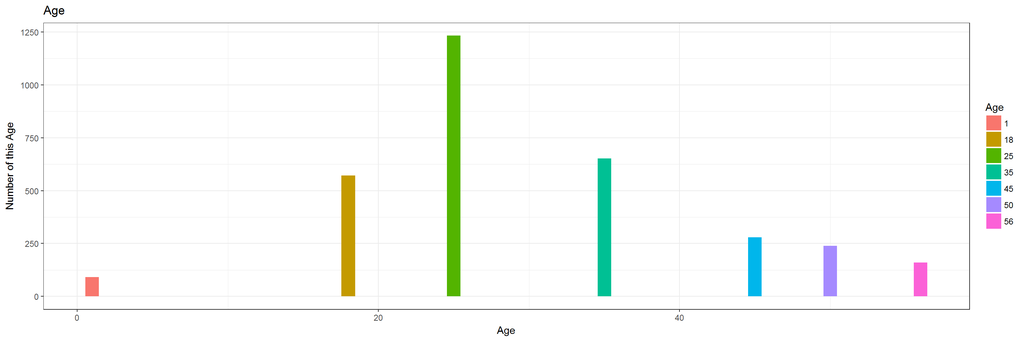

```r
ggplot(data=user_freq, aes(x=Age, fill=Agefill)) +
    geom_bar() +
    ggtitle("Age") +
    labs(y="Number of this Age", x="Age", fill = "Age") +
    theme_bw()
```

now from the result we can see that some observers have the age equal to 1, then they are not valid data, we need to clean them

```r
newraitings = newraitings[newraitings$Age != 1, ]
user_freq = user_freq[user_freq$Age != 1, ]
table(user_freq$Age)
```

```
##
##   18   25   35   45   50   56
##  571 1232  652  280  239  160
```

Then the age can divide into six group, 18 25 35 45 50 56

```r
library(psych)
# define the function first
get_best_movies = function(age, number = 10){
    bestmovie = as.matrix(head(sort(table(newraitings[newraitings$Age==age,]$movie), decreasing = TRUE),number))
    bestmovie = as.data.frame(bestmovie)
    names(bestmovie) = "count"
    bestmovie = cbind("movie_id" = rownames(bestmovie), bestmovie)
    rownames(bestmovie) <- NULL

    k = 1
    for (i in bestmovie$movie_id){
    temp_row = data.frame(movie[movie$MovieID == i, c(2, 3)])
    if (k == 1){
        temp_get = temp_row
        k = 0
    }
    else{
        temp_get = rbind(temp_get, temp_row)
    }
}
    bestmovie = cbind(bestmovie[1:nrow(temp_get),], temp_get)
    return(bestmovie)

}

# Then run the function to get the result:
# for the group age 18
bestmovie2 = get_best_movies(18)
bestmovie2$Title
```

```
##  [1] American Beauty (1999)
##  [2] Matrix, The (1999)
##  [3] Shawshank Redemption, The (1994)
##  [4] Star Wars: Episode V - The Empire Strikes Back (1980)
##  [5] Usual Suspects, The (1995)
##  [6] Star Wars: Episode IV - A New Hope (1977)
##  [7] Braveheart (1995)
##  [8] Princess Bride, The (1987)
##  [9] Pulp Fiction (1994)
## [10] Being John Malkovich (1999)
## 3883 Levels: Not Love, Just Frenzy (M閱\xa9 que amor, frenes? (1996) ...
```

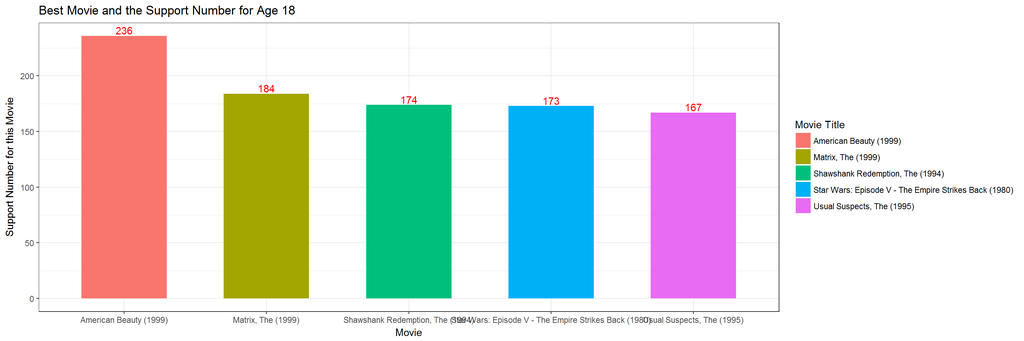

```r
draw_best_movie(bestmovie2, figuretitle = "Best Movie and the Support Number for Age 18")
```

```r
# for the group age 25
bestmovie2 = get_best_movies(25)
bestmovie2$Title
```

```
##  [1] Star Wars: Episode IV - A New Hope (1977)
##  [2] American Beauty (1999)
##  [3] Raiders of the Lost Ark (1981)
##  [4] Star Wars: Episode V - The Empire Strikes Back (1980)
##  [5] Matrix, The (1999)
##  [6] Sixth Sense, The (1999)
##  [7] Shawshank Redemption, The (1994)
##  [8] Silence of the Lambs, The (1991)
##  [9] Princess Bride, The (1987)
## [10] Godfather, The (1972)
## 3883 Levels: Not Love, Just Frenzy (M閱\xa9 que amor, frenes? (1996) ...
```

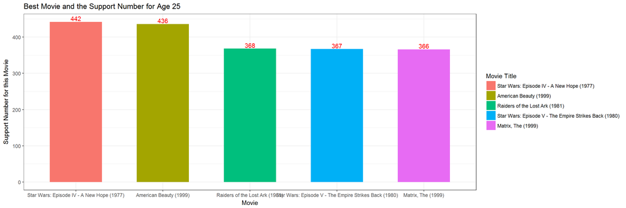

```r
draw_best_movie(bestmovie2, figuretitle = "Best Movie and the Support Number for Age 25")
```

```r
# for the group age 35
bestmovie2 = get_best_movies(35)
bestmovie2$Title
```

```
##  [1] Star Wars: Episode IV - A New Hope (1977)
##  [2] American Beauty (1999)
##  [3] Raiders of the Lost Ark (1981)
##  [4] Godfather, The (1972)
##  [5] Sixth Sense, The (1999)
##  [6] Saving Private Ryan (1998)
##  [7] Silence of the Lambs, The (1991)
##  [8] Princess Bride, The (1987)
##  [9] Schindler's List (1993)
## [10] Fargo (1996)
## 3883 Levels: Not Love, Just Frenzy (M閱\xa9 que amor, frenes? (1996) ...
```

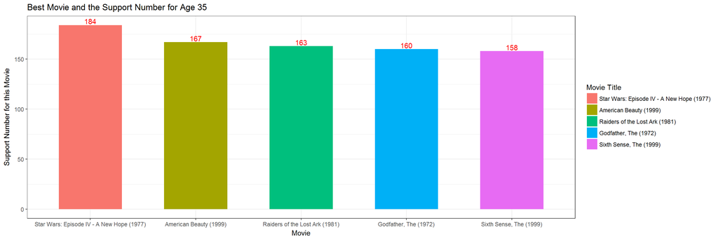

```r
draw_best_movie(bestmovie2, figuretitle = "Best Movie and the Support Number for Age 35")
```

```r
# for the group age 45
bestmovie2 = get_best_movies(45)
bestmovie2$Title
```

```
##  [1] Star Wars: Episode IV - A New Hope (1977)
##  [2] Schindler's List (1993)
##  [3] Godfather, The (1972)
##  [4] Casablanca (1942)
##  [5] American Beauty (1999)
##  [6] Dr. Strangelove or: How I Learned to Stop Worrying and Love the Bomb (1963)
##  [7] Raiders of the Lost Ark (1981)
##  [8] Fargo (1996)
##  [9] Shawshank Redemption, The (1994)
## [10] 2001: A Space Odyssey (1968)
## 3883 Levels: Not Love, Just Frenzy (M閱\xa9 que amor, frenes? (1996) ...
```

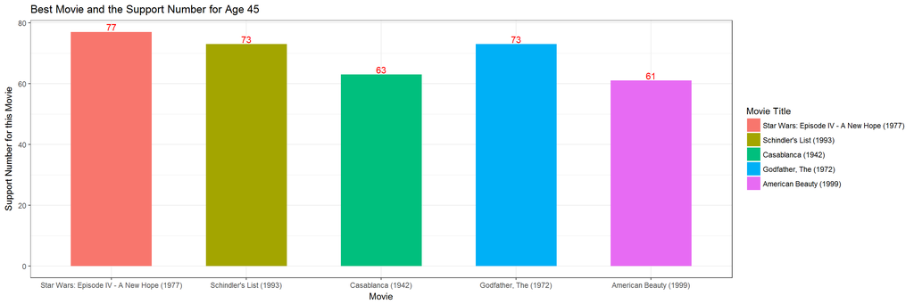

```r
draw_best_movie(bestmovie2, figuretitle = "Best Movie and the Support Number for Age 45")
```

```r
# for the group age 50
bestmovie2 = get_best_movies(50)
bestmovie2$Title
```

```
##  [1] Godfather, The (1972)
##  [2] Star Wars: Episode IV - A New Hope (1977)
##  [3] Casablanca (1942)
##  [4] Fargo (1996)
##  [5] American Beauty (1999)
##  [6] Shakespeare in Love (1998)
##  [7] Schindler's List (1993)
##  [8] Chinatown (1974)
##  [9] Butch Cassidy and the Sundance Kid (1969)
## [10] Dr. Strangelove or: How I Learned to Stop Worrying and Love the Bomb (1963)
## 3883 Levels: Not Love, Just Frenzy (M閱\xa9 que amor, frenes? (1996) ...
```

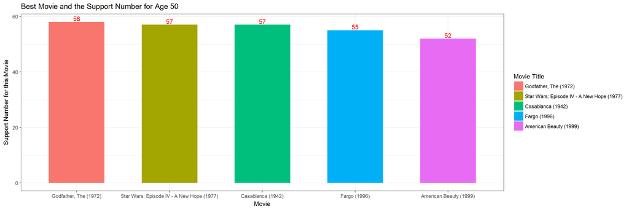

```r
draw_best_movie(bestmovie2, figuretitle = "Best Movie and the Support Number for Age 50")
```

```r
# for the group age 56
bestmovie2 = get_best_movies(56)
bestmovie2$Title
```

```
##  [1] Godfather, The (1972)
##  [2] Schindler's List (1993)
##  [3] American Beauty (1999)
##  [4] Casablanca (1942)
##  [5] African Queen, The (1951)
##  [6] One Flew Over the Cuckoo's Nest (1975)
##  [7] Wizard of Oz, The (1939)
##  [8] Maltese Falcon, The (1941)
##  [9] Butch Cassidy and the Sundance Kid (1969)
## [10] Saving Private Ryan (1998)
## 3883 Levels: Not Love, Just Frenzy (M閱\xa9 que amor, frenes? (1996) ...
```

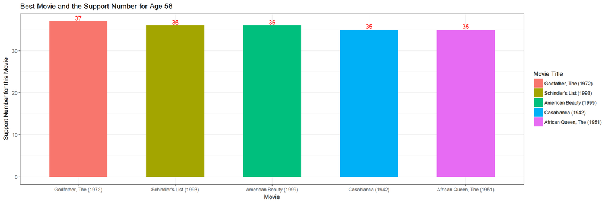

```r
draw_best_movie(bestmovie2, figuretitle = "Best Movie and the Support Number for Age 56")
```

3. use the model to do the prediction

we need to reload the RData for newraitings

```r
load("newraitings.RData")
```

get the columns we want out

```r
trainingset = subset(newraitings, select = c(2,5,6,7,3))
```

let’s see the structure of the data

```r
str(trainingset)
```

```
## 'data.frame':    28797 obs. of  5 variables:
##  $ movie     : int  1253 589 1270 1274 741 750 924 2407 3070 208 ...
##  $ Gender    : Factor w/ 2 levels "F","M": 2 2 2 2 2 2 2 2 2 2 ...
##  $ Age       : int  45 45 45 45 45 45 45 45 45 45 ...
##  $ Occupation: int  17 17 17 17 17 17 17 17 17 17 ...
##  $ rating    : int  5 5 4 4 5 5 5 4 3 1 ...
```

```r
summary(trainingset)
```

```
##      movie      Gender         Age          Occupation         rating
##  Min.   :   1   F: 7565   Min.   : 1.00   Min.   : 0.000   Min.   :1.000
##  1st Qu.:1017   M:21232   1st Qu.:25.00   1st Qu.: 3.000   1st Qu.:3.000
##  Median :1748             Median :25.00   Median : 7.000   Median :4.000
##  Mean   :1836             Mean   :28.32   Mean   : 8.486   Mean   :3.633
##  3rd Qu.:2722             3rd Qu.:35.00   3rd Qu.:14.000   3rd Qu.:4.000
##  Max.   :3952             Max.   :56.00   Max.   :20.000   Max.   :5.000
```

```r
# set some variables to factor
trainingset$Occupation = as.character(trainingset$Occupation)
trainingset$Gender = as.character(trainingset$Gender)
str(trainingset)
```

```
## 'data.frame':    28797 obs. of  5 variables:
##  $ movie     : int  1253 589 1270 1274 741 750 924 2407 3070 208 ...
##  $ Gender    : chr  "M" "M" "M" "M" ...
##  $ Age       : int  45 45 45 45 45 45 45 45 45 45 ...
##  $ Occupation: chr  "17" "17" "17" "17" ...
##  $ rating    : int  5 5 4 4 5 5 5 4 3 1 ...
```

assemble the test set

```r
# sample_submission = read.csv("sample_submission.csv", sep = ",", header = TRUE, col.names = c("user","rating","id"))
# save(sample_submission, file = "sample_submission.RData")
load("sample_submission.RData")
testset = sample_submission[,c(1,3)]
testset$id = gsub("\\d+_", "", testset$id)
colnames(testset) = c("user", "movie")
# because we have over 500000 data in the test set, we can only choose about 2000 out to get the result
require(caret)
seed = as.numeric(as.Date("2017-04-12"))
set.seed(seed)
inTrain = createDataPartition(testset$user, p=0.004)
testset <- testset[inTrain[[1]],]
testset = combine_user(users, testset, 6040)
# testset = testset[,c(2,3,4,5)]
rownames(testset) = NULL

# see the structure
str(trainingset)
```

```
## 'data.frame':    28797 obs. of  5 variables:
##  $ movie     : int  1253 589 1270 1274 741 750 924 2407 3070 208 ...
##  $ Gender    : chr  "M" "M" "M" "M" ...
##  $ Age       : int  45 45 45 45 45 45 45 45 45 45 ...
##  $ Occupation: chr  "17" "17" "17" "17" ...
##  $ rating    : int  5 5 4 4 5 5 5 4 3 1 ...
```

```r
str(testset)
```

```
## 'data.frame':    2002 obs. of  5 variables:
##  $ user      : int  5 8 10 10 15 18 18 23 26 33 ...
##  $ movie     : chr  "1715" "1" "1357" "3066" ...
##  $ Gender    : Factor w/ 2 levels "F","M": 2 2 1 1 2 1 1 2 2 2 ...
##  $ Age       : int  25 25 35 35 25 18 18 35 25 45 ...
##  $ Occupation: int  20 12 1 1 7 3 3 0 7 3 ...
```

```r
testset$Gender = as.character(testset$Gender)
testset$Occupation = as.character(testset$Occupation)
testset$movie = as.integer(testset$movie)

rating = c(rep(NA, nrow(testset)))
testset = cbind(testset, rating)
```

#### slope one

```r
set_ratings = function(movie_id){
    return(mean(trainingset[movie==movie_id,5]))
}
for (i in 1:nrow(testset)){
    testset[i,6] = round(set_ratings(testset[i,1]), 1)
    if (is.na(testset[i,6])){
        testset[i,6] = 5
    }
}

# set the output submission
submission <- testset[,c("user", "rating")]
id = c(paste(as.character(testset$user),"_",as.character(testset$movie),sep=""))
submission = cbind(submission, id)
write.table(submission, file = "submission.csv",
            col.names = TRUE, row.names = FALSE, sep = ",")
```

#### KNN

```r
library(class)
require(caret)
seed = as.numeric(as.Date("2017-04-12"))
set.seed(seed)
inTrain = createDataPartition(trainingset$rating, p=0.7)
testset = trainingset[-inTrain[[1]],]
trainingset <- trainingset[inTrain[[1]],]
dealwithdata = function(dataset){
    dataset$movie = as.integer(dataset$movie)
    for (i in 1:nrow(dataset)){
        if (dataset[i,2]=="M"){
            dataset[i,2]=1
        }
        else{
            dataset[i,2]=2
        }
    }
    dataset$Gender = as.integer(dataset$Gender)
    dataset$Occupation = as.integer(dataset$Occupation)
    return(dataset)
}
trainingset = dealwithdata(trainingset)
testset = dealwithdata(testset)
knn.pred = knn(trainingset,testset,trainingset$rating, k = 4)
confusionMatrix(knn.pred, testset$rating)
```

```
## Confusion Matrix and Statistics
##
##           Reference
## Prediction    1    2    3    4    5
##          1   45   43   48   20   11
##          2   49  124  189  136   38
##          3  138  361  806  722  271
##          4   97  306  978 1540  832
##          5   25   72  297  624  866
##
## Overall Statistics
##
##                Accuracy : 0.3914
##                  95% CI : (0.3811, 0.4018)
##     No Information Rate : 0.3522
##     P-Value [Acc > NIR] : 1.91e-14
##
##                   Kappa : 0.1516
##  Mcnemar's Test P-Value : < 2.2e-16
##
## Statistics by Class:
##
##                      Class: 1 Class: 2 Class: 3 Class: 4 Class: 5
## Sensitivity           0.12712  0.13687  0.34771   0.5062   0.4291
## Specificity           0.98527  0.94671  0.76392   0.6045   0.8462
## Pos Pred Value        0.26946  0.23134  0.35074   0.4103   0.4597
## Neg Pred Value        0.96352  0.90348  0.76151   0.6925   0.8294
## Prevalence            0.04098  0.10489  0.26835   0.3522   0.2336
## Detection Rate        0.00521  0.01436  0.09331   0.1783   0.1003
## Detection Prevalence  0.01933  0.06205  0.26603   0.4345   0.2181
## Balanced Accuracy     0.55620  0.54179  0.55582   0.5554   0.6377
```